# Effect of Players Characteristics on Their Values

## Investigation Overview

> The main goal of this investigation was to find out what Characteristics could be used to predict player value. The main focus was on player Overall, Ball Control, International Reputation, and Body Type.

## Dataset Overview

> The dataset inlcude Innformation about more than 18K players from FIFA19 game, with all thier characteristics, and thier values.

```python
# import all packages and set plots to be embedded inline
import numpy as np
import pandas as pd
import matplotlib.pyplot as plt
import seaborn as sb

%matplotlib inline

# suppress warnings from final output
import warnings
warnings.simplefilter("ignore")
```

```python
# load in the dataset into a pandas dataframe
df = pd.read_csv("FIFA19.csv")
```

```python
# Get only most interesting columns
df = df[['Name', 'Age', 'Nationality', 'Overall', 'Club','Preferred Foot',
         'Body Type', 'Position', 'Height', 'Weight', 'Finishing', 'Dribbling'
         ,'Crossing', 'BallControl', 'Acceleration', 'Wage','International Reputation', 'Reactions', 'Value']]
# Drop nan values and incorrect value
df.dropna(inplace=True)
df = df[df['Body Type'].isin(['Lean', 'Normal', "Stocky"])]

# Define faunction to extract the number value from the string
def func(s):
        return eval(s.replace('€', '').replace('M', "*1000000").replace('K', '*1000'))

# Convert height from foot to cm and save it as float
df['Height'] = df['Height'].apply(lambda x: round(float(x.replace("'", '.'))*30.48),2)
df['Weight'] = df['Weight'].apply(lambda x: round(float(x.split('l')[0])*0.453592,2))
df['Wage'] = df['Wage'].apply(func)
df['Value']= df['Value'].apply(func)
```

## Values Distribution

> Players Values take on a very large range of values, from less than 10K ,𝑡𝑜 𝑎𝑏𝑜𝑢𝑡 102 million at the highest. Plotted on a logarithmic scale, the distribution of player values takes on a Normal shape.

```
''
```

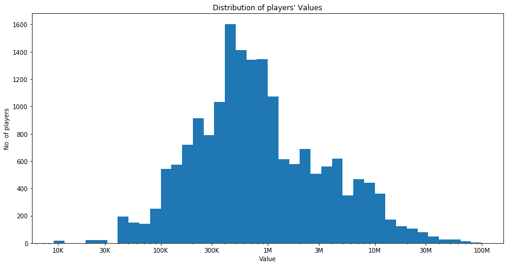

```python
xticks = ['10K','30K','100K','300K',"1M","3M","10M","30M","100M"]
bins = 10 ** np.arange(4, 8+0.1, 0.1)

plt.figure(figsize=(14,7))
plt.hist(df['Value'], bins=bins)
plt.xscale('log')
plt.xticks([10**4+1000, 3*10**4, 10**5, 3*10**5, 10**6, 3*10**6, 10**7, 3*10**7, 10**8], xticks)
plt.title("Distribution of players' Values")
plt.xlabel("Value")
plt.ylabel("No. of players")
;
```

## Distribution of Overall

> Player Overall is considered the main indicator of how good is the player in matches. The distribution looks normally disrtibuted, with most players overall around 67

```
''
```

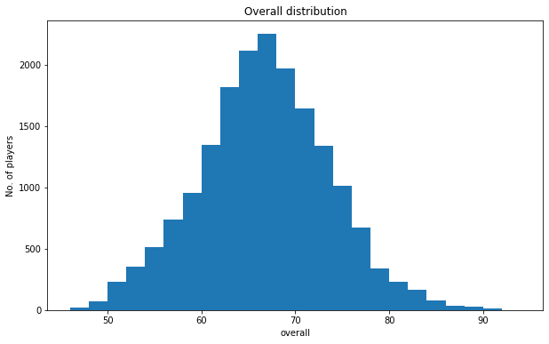

```python
plt.figure(figsize=(10,6))

b = np.arange(46, 94+2, 2)
plt.hist(df['Overall'], bins=b)
plt.title("Overall distribution")
plt.xlabel("overall")
plt.ylabel('No. of players')
;
```

## Value vs. Player Overall

```
''
```

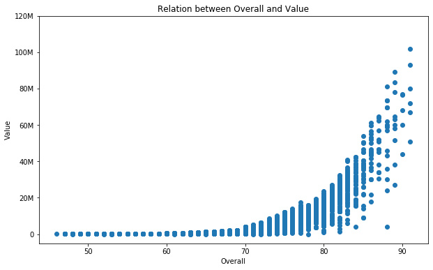

```python
plt.figure(figsize=(10,6))
plt.scatter(data=df, x='Overall', y='Value')
plt.title("Relation between Overall and Value")
plt.yticks([0.0e+00,  2.0e+07,  4.0e+07,  6.0e+07,  8.0e+07,1.0e+08,  1.2e+08],
            ['0', '20M', '40M', '60M', '80M', '100M', '120M'])
plt.xlabel('Overall')
plt.ylabel('Value')
;
```

## Value vs. Ball Control

> ball control above 40 seems to be related to player value.

```
''
```

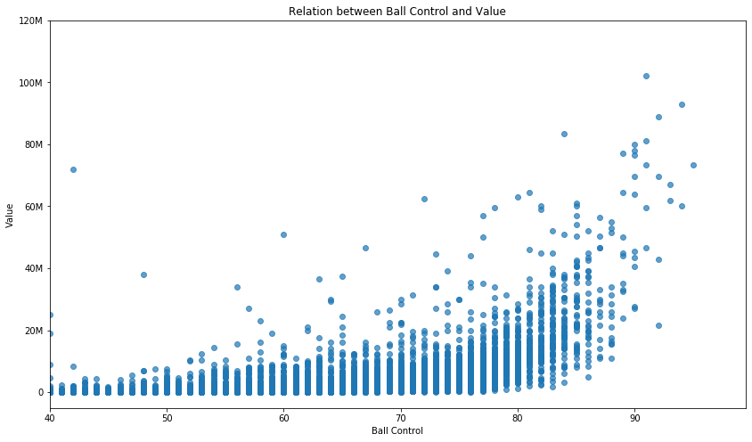

```python
plt.figure(figsize=(14,8))
plt.scatter(data=df, x='BallControl', y='Value', alpha=0.7)
plt.title("Relation between Ball Control and Value")
plt.yticks([0.0e+00,  2.0e+07,  4.0e+07,  6.0e+07,  8.0e+07,1.0e+08,  1.2e+08],
            ['0', '20M', '40M', '60M', '80M', '100M', '120M'])
plt.xlabel('Ball Control')
plt.ylabel('Value')
plt.xlim(40)
;
```

## Value - Position Relationship

> player value depends on his position. The highest mean values are for Left Forward.

```
''
```

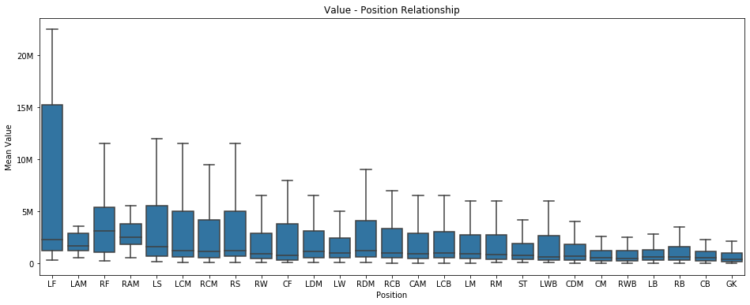

```python
default_color = sb.color_palette()[0]
# Lets get position arder based on mean
position_order = df.groupby("Position").mean()['Value'].sort_values(ascending=False).index

plt.figure(figsize=(16,6))
sb.boxplot(data=df, x='Position', y='Value',showfliers = False, color=default_color, order=position_order)
plt.yticks([0.0e+00,  0.5e+07,  1e+07,  1.5e+07,  2.0e+07],
            ['0', '5M', '10M', '15M', '20M'])
plt.ylabel("Mean Value")
plt.title('Value - Position Relationship')
;
```

## International-Reputation and Value relationship

> The More the player is popular, the higher value he has.

```
''
```

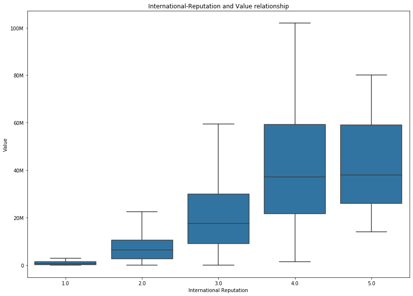

```python
plt.figure(figsize=(14,10))
sb.boxplot(data=df, x='International Reputation', y='Value',showfliers = False, color=default_color)
plt.title("International-Reputation and Value relationship")
plt.yticks([0,  0.2e+08,  0.4e+08,  0.6e+08,  0.8e+08,  1e+08], ["0",  "20M",  "40M",  "60M",  "80M",  '100M'])
;
```